# Diamonds Group Project 2

Vinnie Gambotto, Steve Meadows, Sai Sreyaa Krishna Mallemala

2025-11-20

# 1 Predicting Educational Success

Understanding the factors that contribute to students’ academic success has become increasingly important, especially as schools, families, and community partners seek effective ways to support K–12 learners. In this project, we analyze data from the Parent and Family Involvement (PFI) in Education Survey, a nationally representative dataset collected by the U.S. Census Bureau, to explore relationships between family engagement, school choice, and student academic outcomes.

Our goal is to identify which aspects of family involvement—such as participation in school activities, communication with teachers, assistance with homework, and perceptions of school quality—are most strongly associated with markers of academic success. Using a range of Generalized Linear Models (GLMs) and classification tools, including logistic regression, multinomial regression, Poisson regression, and Linear and Quadratic Discriminant Analysis (LDA/QDA), we aim to build predictive models that highlight the most influential variables.

By applying these statistical learning methods through the tidymodels framework, we address the broader research question:

**Which family and school-related factors best predict student academic success, and how can these insights guide effective support strategies for K–12 students?**

The final results will be presented in a concise report that summarizes both our modeling process and our key findings. Ultimately, our analysis is designed to provide actionable insights for GVSU’s K–12 Connect initiative, helping inform recommendations that support students, empower families, and strengthen school–family partnerships.

# 2 Data Loading and Preprocessing

We began by loading the 2019 Parent and Family Involvement (PFI) data from the curated Excel file and standardizing the grade variable (ALLGRADEX) so that Kindergarten categories were collapsed into a single value and grades 1–12 were mapped onto a consistent 1–12 scale. From this standardized variable, we restricted the analytic sample to high school students only (grades 6–12). Next, we cleaned the outcome variable SEGRADES by treating special codes (-1 and 5) as missing, dropping cases with missing SEGRADES, and then recoding SEGRADES into a binary achievement indicator: students reporting mostly A’s/B’s (categories 1–2) were labeled “high” and those reporting mostly C’s or lower (categories 3–4) were labeled “low.” Finally, we removed a set of identifying or analytically unnecessary variables (e.g., ZIP code, date of birth fields, interview identifiers, and raw grade variables) to produce a streamlined dataset focused on high school students and a clean binary academic success outcome.

```r
library(readxl)


# Load and preprocess the data
df_2019 <- read_excel("pfi-data.xlsx", sheet = "curated 2019")

# Standardizing ALLGRADEX for 2019 data
df_2019 <- df_2019 %>%
  mutate(
    ALLGRADEX_2019raw = ALLGRADEX,
    ALLGRADEX_std = case_when(
      ALLGRADEX %in% c(2, 3) ~ 0,                       # both K flavors → Kindergarten
      ALLGRADEX >= 4 & ALLGRADEX <= 15 ~ ALLGRADEX - 3, # 1st–12th → 1–12
      TRUE ~ NA_real_
    )
  )

# Filtering for high school students only
df <- df_2019 %>%
  filter(ALLGRADEX_std >= 6 & ALLGRADEX_std <= 12)


# Handling target variable classes and missing values
df <- df %>%
  # turn -1 and 5 into NA
  mutate(SEGRADES = na_if(SEGRADES, -1),
         SEGRADES = na_if(SEGRADES, 5)) %>%

  # drop rows where SEGRADES is missing
  filter(!is.na(SEGRADES)) %>%

  # create binary target: high vs low
  mutate(
    success = case_when(
      SEGRADES %in% c(1, 2) ~ "high",
      SEGRADES %in% c(3, 4) ~ "low"
    ),
    success = factor(success, levels = c("low", "high"))
  )

# Removing all unnecessary variables
df <- df %>%
  select(-ZIPLOCL, -CDOBMM, -CDOBYY, -BASMID, -ALLGRADEX_std, -MOSTIMPT, -INTNUM, -ALLGRADEX_2019raw, -ALLGRADEX, -SEGRADES, - HHPARN19_BRD)
```

# 3 LDA

```r
levels(df$success)
```

```
## [1] "low"  "high"
```

## 3.1 Choosing predictors for LDA

We are using these predictors as they make sense for grades:

HHPARN19X – number of parents in the household EDCPUB – public vs other SCCHOICE – school choice EINTNET – internet at home SCHLHRSWK – school hours per week PARGRADEX – parent education NUMSIBSX – number of siblings

```r
predictor_variables <- c(
  "HHPARN19X",  # number of parents in household
  "EDCPUB",     # public vs other school
  "SCCHOICE",   # school choice
  "EINTNET",    # internet at home
  "SCHLHRSWK",  # school hours per week
  "PARGRADEX",  # parent education
  "NUMSIBSX"    # number of siblings
)
```

```r
df_model <- df %>%
select(success, all_of(predictor_variables))
```

This step updates the dataset to keep only the response variable success along with the seven predictors that will be used in the LDA model. These predictors are for family structure, school type, school choice, internet access, school hours, parent education, and number of siblings.

## 3.2 Checking whether all variables are numeric

```r
df_model %>%
  summarise(across(all_of(predictor_variables), ~ class(.)))
```

```
## # A tibble: 1 × 7
##   HHPARN19X EDCPUB  SCCHOICE EINTNET SCHLHRSWK PARGRADEX NUMSIBSX
##   <chr>     <chr>   <chr>    <chr>   <chr>     <chr>     <chr>
## 1 numeric   numeric numeric  numeric numeric   numeric   numeric
```

## 3.3 Test-Train Data

```r
set.seed(123)

data_split <- initial_split(df_model, prop = 0.8, strata = success)
train_data <- training(data_split)
test_data  <- testing(data_split)
nrow(train_data)
```

```
## [1] 7472
```

```r
nrow(test_data)
```

```
## [1] 1869
```

Stratified sampling based on the success variable is used to divide the data into an 80% training set and a 20% test set, preserving the same proportion of low and high success cases in both sets. This results in 7,472 observations for the training set and 1,869 observations for the test set. We train the LDA model on the training portion and evaluate the performance of the model using the test portion.

## 3.4 Fitting the LDA Model

```r
lda_model <- discrim_linear() %>%
  set_mode("classification") %>%
  set_engine("MASS", prior = c(low = 0.5, high = 0.5)) %>%
  fit(
    success ~ HHPARN19X + EDCPUB + SCCHOICE +
      EINTNET + SCHLHRSWK + PARGRADEX + NUMSIBSX,
    data = train_data
  )

lda_model
```

```
## parsnip model object
##
## Call:
## lda(success ~ HHPARN19X + EDCPUB + SCCHOICE + EINTNET + SCHLHRSWK +
##     PARGRADEX + NUMSIBSX, data = data, prior = ~c(low = 0.5,
##     high = 0.5))
##
## Prior probabilities of groups:
##  low high
##  0.5  0.5
##
## Group means:
##      HHPARN19X   EDCPUB SCCHOICE  EINTNET SCHLHRSWK PARGRADEX  NUMSIBSX
## low   1.786437 1.042510 1.471660 3.872470  3.688259  3.126518 0.9321862
## high  1.409007 1.111814 1.344695 3.910703  3.776218  3.676434 1.0413325
##
## Coefficients of linear discriminants:
##                   LD1
## HHPARN19X -0.70532349
## EDCPUB     0.68012945
## SCCHOICE  -0.59014236
## EINTNET    0.31094456
## SCHLHRSWK  0.12774174
## PARGRADEX  0.46740115
## NUMSIBSX   0.08922897
```

The LDA model is fit using equal class priors of 0.5 for low success and 0.5 for high success, giving equal weight to both groups during training instead of letting the model automatically favor the majority high-success class. This goes in line with our goal of increasing the detection of the low-success students. These priors are shown at the top of the output, followed by the means of each group: for example, low-success students average values like HHPARN19X = 1.786, EINTNET = 3.872, and PARGRADEX = 3.126, while high-success students have slightly higher values such as EINTNET = 3.910, SCHLHRSMK = 3.776, and PARGRADEX = 3.676. These differences represent how high academic resources and strong parental backgrounds are associated with high success, and how low values on these variables are associated with low success-more generally, information the model then uses to predict which students are at risk.

The discriminant coefficients further show which predictors pull a student toward the “low” classification: negative coefficients such as HHPARN19X (-0.705) and SCCHOICE (-0.590) push the model toward predicting “low success,” whereas positive coefficients such as EDCPUB (0.681), EINTNET (0.310), and PARGRADEX (0.467) shift the predictions toward “high success.” Together, these numerical results show how the model combines predictor patterns to distinguish the students, including specific variables that serve to help highlight those more likely to fall into the low-success category, which meets the main objective of the analysis.

## 3.5 Getting predictions on test data

```r
lda_test <- augment(lda_model, new_data = test_data)
head(lda_test)
```

```
## # A tibble: 6 × 11
##   .pred_class .pred_low .pred_high success HHPARN19X EDCPUB SCCHOICE EINTNET
##   <fct>           <dbl>      <dbl> <fct>       <dbl>  <dbl>    <dbl>   <dbl>
## 1 high            0.275      0.725 high            1      1        1       4
## 2 high            0.275      0.725 high            1      1        1       4
## 3 high            0.348      0.652 high            1      1        2       4
## 4 high            0.376      0.624 high            1      1        2       4
## 5 low             0.517      0.483 high            1      1        2       4
## 6 high            0.236      0.764 high            1      2        1       4
## # ℹ 3 more variables: SCHLHRSWK <dbl>, PARGRADEX <dbl>, NUMSIBSX <dbl>
```

```r
conf_mat(lda_test, truth = success, estimate = .pred_class)
```

```
##           Truth
## Prediction  low high
##       low   144  530
##       high  103 1092
```

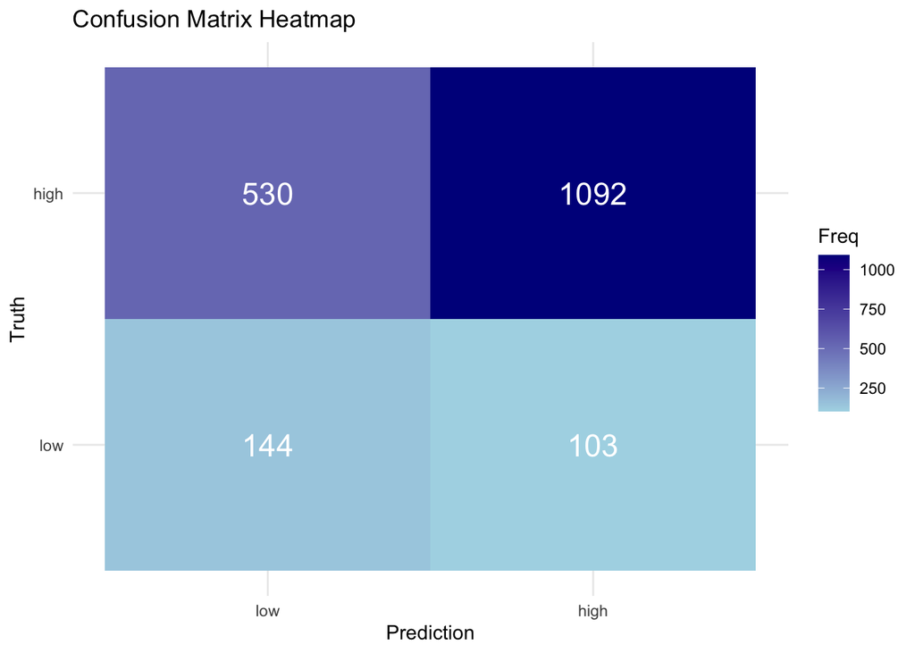

```r
library(ggplot2)
library(dplyr)

cm <- conf_mat(lda_test, truth = success, estimate = .pred_class)

cm_df <- as.data.frame(cm$table)

ggplot(cm_df, aes(x = Prediction, y = Truth, fill = Freq)) +
  geom_tile() +
  geom_text(aes(label = Freq), color = "white", size = 6) +
  scale_fill_gradient(low = "lightblue", high = "darkblue") +
  labs(title = "Confusion Matrix Heatmap") +
  theme_minimal()
```

```r
metrics <- bind_rows(
  accuracy(lda_test, truth = success, estimate = .pred_class),
  precision(lda_test, truth = success, estimate = .pred_class, event_level = "first"),
  recall(lda_test, truth = success, estimate = .pred_class, event_level = "first"),
  f_meas(lda_test, truth = success, estimate = .pred_class, event_level = "first"),
  roc_auc(lda_test, truth = success, .pred_low)
)

metrics
```

```
## # A tibble: 5 × 3
##   .metric   .estimator .estimate
##   <chr>     <chr>          <dbl>
## 1 accuracy  binary         0.661
## 2 precision binary         0.214
## 3 recall    binary         0.583
## 4 f_meas    binary         0.313
## 5 roc_auc   binary         0.672
```

The confusion matrix indicates that this model continues to do well at predicting the high-success students, correctly identifying 1092 of them, but it continues to show weak performance for the low-success group. Of the 247 actual low-success students, only 144 were correctly identified as low, but 103 were misclassified as high, indicating that a large portion of the students that need attention are still missed. This trend is mirrored in the evaluation metrics: the precision for the low-success class is 0.21, which means only 21 percent of the students predicted as low are truly low, while the recall is 0.58, showing that the model captures a little more than half of the actual low-success students. Confirming this finding, the F1-score, balancing precision and recall, is 0.31 and thus again shows the model’s poor ability to reliably flag low-performing students. Even though the overall accuracy is 66.13 percent, this is driven mainly by strong performance on the high-success group and does not reflect meaningful progress toward identifying low-success students. At the same time, the ROC AUC value of 0.67 indicates only moderate ability to correctly rank students based on their likelihood of having low success. In all, results indicate that even though the model may perform appropriately for high-success students, it is pretty limited with respect to detecting low-success students, which is actually the main challenge for this analysis.

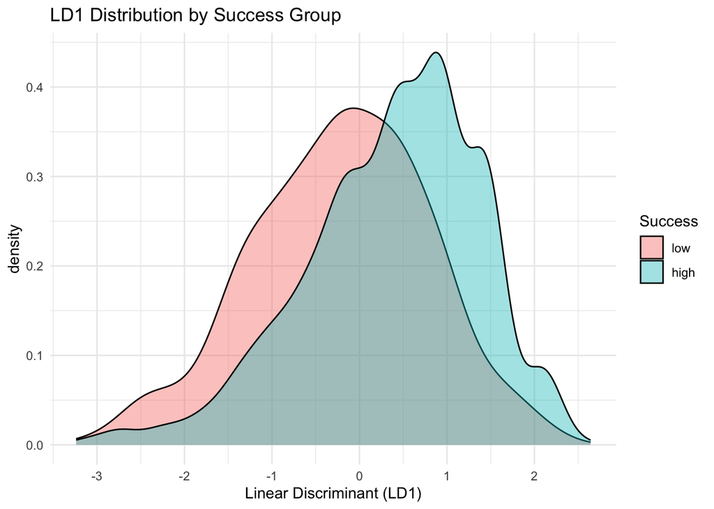

```r
library(dplyr)
library(ggplot2)

# 1. Getting the underlying MASS::lda object from the parsnip model
lda_engine <- lda_model$fit

# 2. Predicting discriminant scores on the test data
lda_scores <- predict(lda_engine, newdata = test_data)

# 3. Add LD1 (first discriminant) as a new column to test_data
lda_values <- test_data %>%
  mutate(LD1 = lda_scores$x[, 1])

# 4. Plot LD1 distribution by success group
ggplot(lda_values, aes(x = LD1, fill = success)) +
  geom_density(alpha = 0.4) +
  labs(
    title = "LD1 Distribution by Success Group",
    x = "Linear Discriminant (LD1)",
    fill = "Success"
  ) +
  theme_minimal()
```

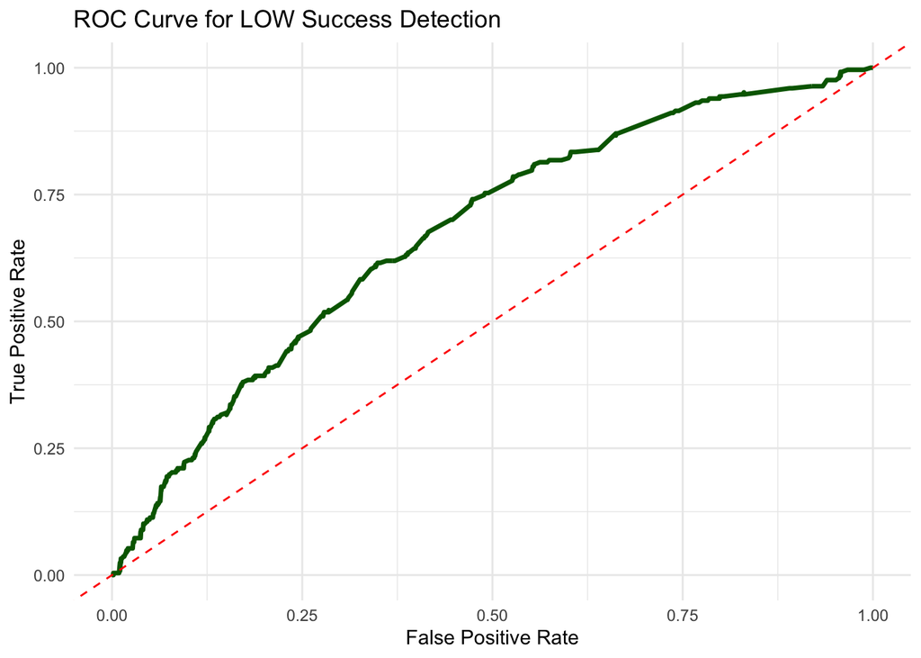

```r
library(ggplot2)

# ROC curve data
roc_data <- roc_curve(lda_test, truth = success, .pred_low)


ggplot(roc_data, aes(x = 1 - specificity, y = sensitivity)) +
geom_line(color="darkgreen", size=1.2) +
geom_abline(linetype="dashed", color="red") +
labs(title="ROC Curve for LOW Success Detection",
x="False Positive Rate",
y="True Positive Rate") +
theme_minimal()
```

The ROC curve shows how well the model can detect low-success students by comparing the true positive rate to the false positive rate across different thresholds. It rises above the diagonal line, which means the model does better than random guessing but not by a large margin. The curving of this ROC is moderate, matching the ROC AUC of about 0.67. That indicates the model has only limited ability in distinguishing between low-success and high-success students. Sometimes it picks up the signal for the low group, but not strongly or consistently. Overall, the ROC curve confirms that detecting low-success students remains challenging, directly related to our project goal of early identification of low performers.

## 3.6 Conclusion

# 4 Lasso Logistic Regression

To try a logistic regression method for our Predicting Educational Success, we decided to use the LASSO regression method with our response variable still being SEGRADES. We decided to remove any rows that are missing to keep a better data set as it was large enough without including the missing variables. We continued with the categorical response of High grade earners being those who had received mostly A’s and B’s and our Low grade earners, those with C’s or D’s.

We chose to do LASSO regression because of how large the raw data set is. With LASSO we can quickly eliminate any predictors that have little to no use for our model or the question we are trying to solve. And with it, our issues with over fitting and multicollinearity are automatically solved within our program and we do not have to do any VIF checks or worry about including too many or too little predictors.

```r
df <- df %>%
  mutate(
    across(
      .cols = where(is.numeric),
      .fns = ~ na_if(.x , -1)
    )
  )
```

```r
df_na_count <- df %>%
  filter(if_any(everything(), is.na)) %>%
  summarise(rows_with_na = n())

kable(df_na_count, caption = "Number of Rows with Any Missing Values")
```

Number of Rows with Any Missing Values

| rows_with_na |
| --- |
| 2082 |

```r
df<-df %>% drop_na()
```

```r
na_count <- df %>%
  filter(if_any(everything(), is.na)) %>%
  summarise(rows_with_na = n())


kable(na_count, caption = "Number of Rows with Any Missing Values")
```

Number of Rows with Any Missing Values

| rows_with_na |
| --- |
| 0 |

Separate our numerical variables from the rest of our data to make cleaning out the -1, 0, and 5 values with SEGRADES easier.

```r
num_vars <- c(
  "FHWKHRS",
  "FSFREQ",
  "HHTOTALXX",
  "P1HRSWK",
  "P1MTHSWRK",
  "P1AGE",
  "NUMSIBSX"
)
```

```r
df <- df %>%
  mutate(
    across(
      .cols = where(is.numeric) & !all_of(num_vars),
      .fns = ~ ifelse(.x < 0, 0, .x)
    )
  )
```

Separate into our test and training set. We will use the training set to run our model. From there we will use the test data for our evaluation. We will then see how well our testing set does later on with this model.

```r
set.seed(1986)

data_split <- initial_split(df, prop = 0.8, strata = success)
train <- training(data_split)
test <- testing(data_split)
```

```r
train_x <- train %>% select(-success)
test_x  <- test  %>% select(-success)
train_x_matrix <- model.matrix(~ . - success - 1, data = train)
test_x_matrix  <- model.matrix(~ . - success - 1, data = test)

train_y <- train$success
test_y <- test$success
```

## 4.1 Building our LASSO model.

```r
lasso.mod <- glmnet(
  x = train_x_matrix,
  y = train_y,
  alpha = 1,
  family = "binomial"
)
```

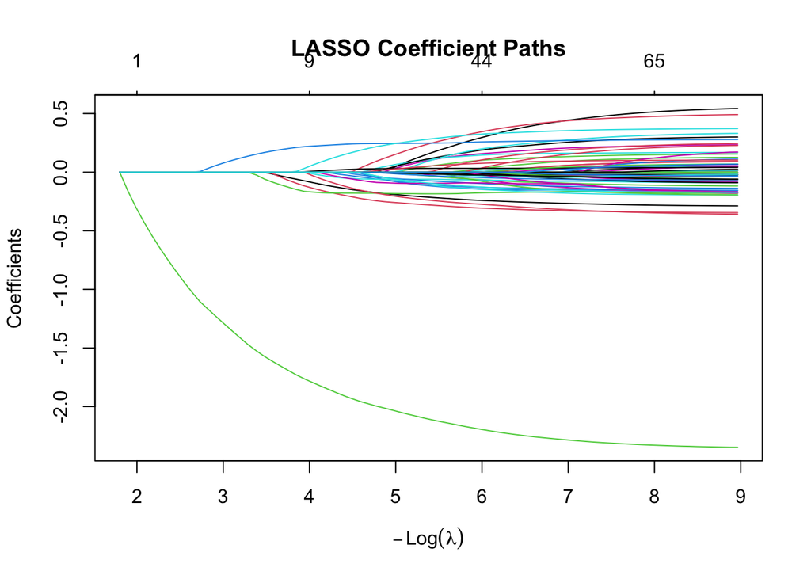

```r
plot(lasso.mod)
title("LASSO Coefficient Paths")
```

Here we can see how each predictor’s coefficient changes as the penalty λ changes. It visualizes variable selection and shrinkage, letting you see which predictors enter the model and when. There are about 6 variables that enter the model early and the rest come around 4.5 for -Log(λ)

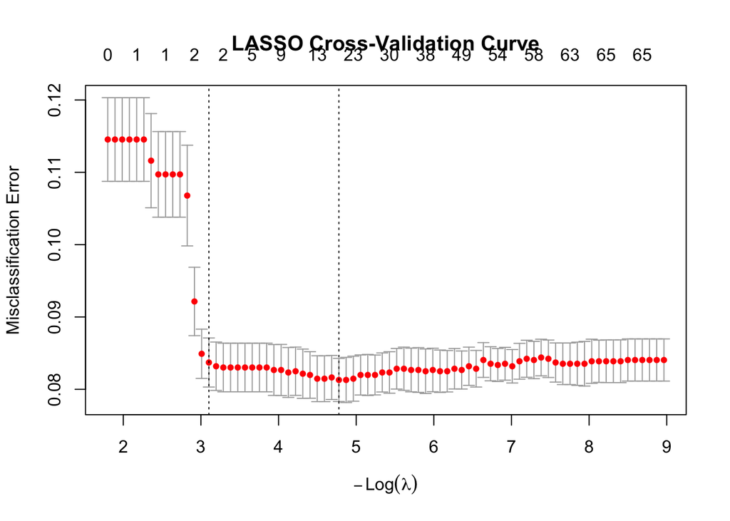

```r
set.seed(1986)

cv.lasso <- cv.glmnet(
  x = train_x_matrix,
  y = train_y,
  alpha = 1,
  family = "binomial",
  type.measure = "class"
)

plot(cv.lasso)
title("LASSO Cross-Validation Curve")
```

Above the plot is suggesting about 22 variables as we see the second dash line crossing right there with the MSE’s. Right around that point, we have a -Log(λ) of between 3 and 5. And below we see that our best λ value is very small at 0.00841625 suggesting that the more predictors we keep the better our prediction model will be.

```r
best_lambda <- cv.lasso$lambda.min
kable(best_lambda)
```

| x |
| --- |
| 0.0084162 |

```r
lasso.final <- glmnet(
  x = train_x_matrix,
  y = train_y,
  alpha = 1,
  lambda = best_lambda,
  family = "binomial"
)

coef_final <- coef(lasso.final)
```

This does work nicely with our MSE plot above as this also concludes with the idea of 22 variables. And the MSE of the 22 variables are better shown below in the table below.

```r
coef_df <- as.data.frame(as.matrix(coef_final)) %>%
  rownames_to_column("variable") %>%
  rename(coef = s0) %>%
  filter(coef != 0)
kable(coef_df)
```

| variable | coef |
| --- | --- |
| (Intercept) | 7.0199913 |
| SEENJOY | -0.1755841 |
| SEABSNT | -0.2441011 |
| SEGRADEQ | -1.9970384 |
| FSSPORTX | -0.0460922 |
| FSCOUNSLR | 0.0330336 |
| FSNOTESX | 0.0032354 |
| FCSCHOOL | -0.1799192 |
| FCTEACHR | -0.0575945 |
| FCSTDS | -0.0597367 |
| FHAMOUNT | -0.0400269 |
| FHCAMT | -0.0332743 |
| CSEX | 0.0940012 |
| RELATION | -0.0011539 |
| P1MRSTA | -0.0013100 |
| TTLHHINC | 0.0290812 |
| OWNRNTHB | -0.1792378 |
| SEFUTUREX | 0.2445361 |
| DSBLTY | 0.2178142 |
| HHPARN19X | -0.0875686 |
| PARGRADEX | 0.0133278 |
| CENREG | -0.0324887 |

```r
lasso.prob <- predict(cv.lasso, newx = test_x_matrix, s = "lambda.min", type = "response")
lasso.pred <- ifelse(lasso.prob > 0.5, "high", "low") %>% factor(levels = c("low", "high"))
mean(lasso.pred == test_y)
```

```
## [1] 0.9160358
```

Our training model gave us a 91.6% correct classification rate with our test data set, suggesting a very strong model that is consistent and reproducible in identifying true lows and false highs.

```r
lasso_table<-table(Predicted = lasso.pred, Actual = test_y)
```

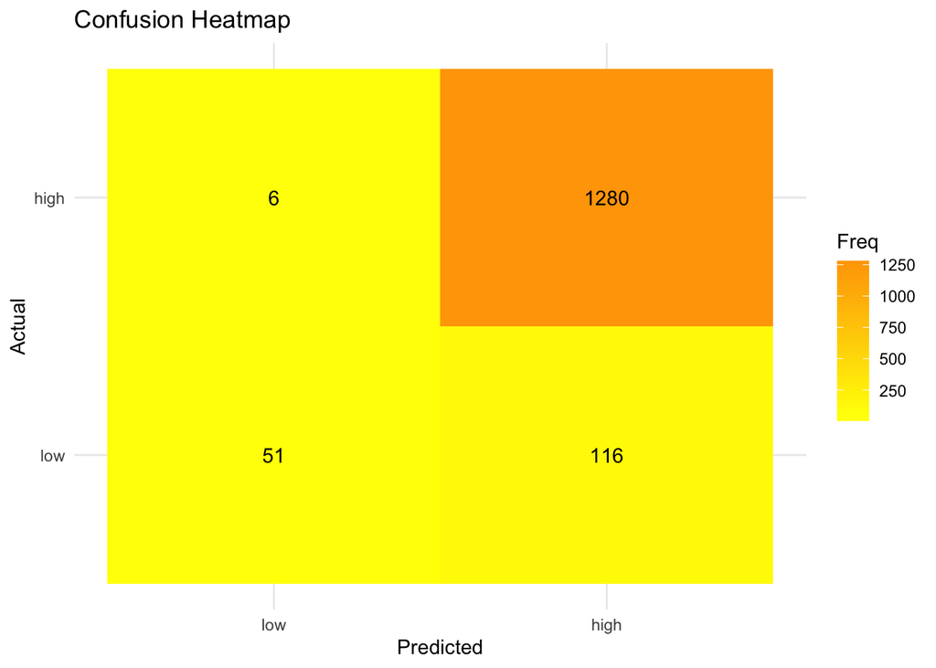

```r
lasso_table<-as.data.frame(lasso_table)
ggplot(lasso_table, aes(x = Predicted, y = Actual, fill = Freq)) +
  geom_tile() +
  geom_text(aes(label = Freq)) +
  scale_fill_gradient(low = 'yellow', high = 'orange') +
  labs(title = "Confusion Heatmap") +
  theme_minimal()
```

```r
roc_obj <- roc(test_y, as.numeric(lasso.prob))
```

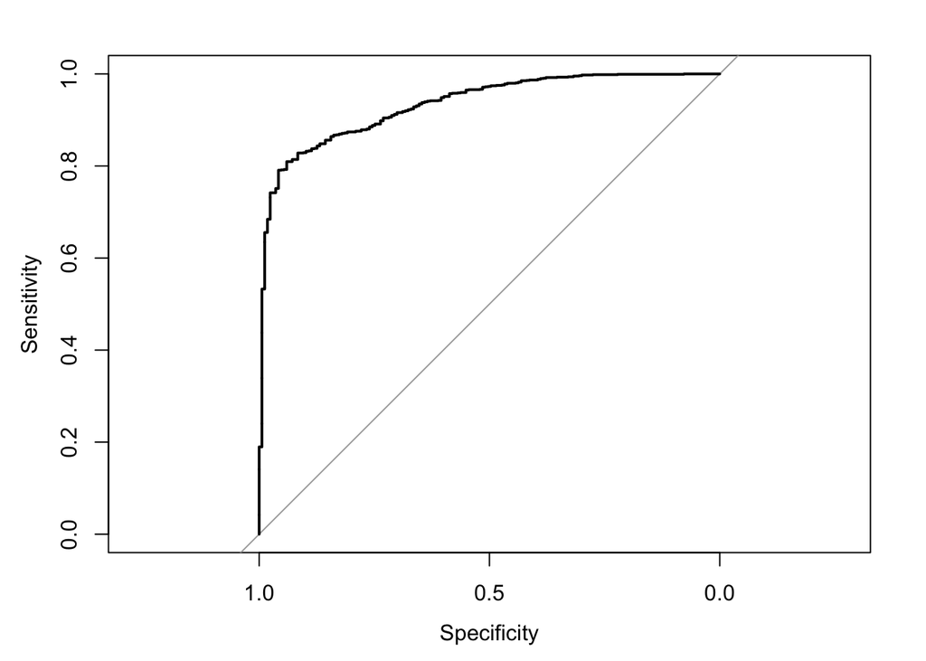

```r
plot(roc_obj)
```

```r
auc(roc_obj)
```

```
## Area under the curve: 0.9337
```

# 5 Support Vector Machines Classifier

After exploring LDA and Lasso Logistic Regression models that we examined in class, we also wanted to implement a Support Vector Classifier (SVC) model to further investigate the predictive power of our features on student academic success. SVC is particularly useful for handling high-dimensional data and can effectively capture complex relationships between variables, and we wanted to experiment with its application in this context to see if it could yield better classification performance compared to the statistical learning models we tested.

We created a pipeline that includes Dimensionality Reduction using the `PCAmixdata` package, followed by SVC modeling using the `e1071` package used in the textbook. We tuned hyperparameters such as the `cost` parameter (C) and `gamma` using cross-validation and parallel baysian optimization to identify the best model using PR-AUC on the minority class as the evaluation metric using the `ParBayesianOptimization` package.

## 5.1 Data Preparation for PCAmix

Prior to fitting the PCAmix model, we undertook several preprocessing steps to ensure compatibility with mixed-data factor extraction. In the PFI dataset, the value `-1` indicates a *valid skip* rather than a substantive numeric response. Because PCAmix replaces missing values in quantitative variables with the column mean, retaining `-1` would introduce artificial values into the covariance structure. We therefore recoded all `-1` entries in numeric variables as `NA`.

For qualitative variables, PCAmix operates on a disjunctive (indicator) matrix in which missing entries are replaced with zeros—an interpretation consistent with the absence of a selected response category in valid-skip cases. Given that the dataset includes both continuous measures (e.g., household size, work hours, parent age) and categorical survey responses, PCAmix is an appropriate framework, as it integrates PCA for quantitative variables with an MCA-like treatment for qualitative variables within a unified component solution. To support this structure, we explicitly identified the small set of metrically continuous variables and converted all remaining predictors to factors.

After generating stratified training and test splits on the binary success outcome, we removed the outcome variable and applied `splitmix()` to decompose the predictor set into quantitative (`X.quanti`) and qualitative (`X.quali`) blocks. This separation is required because PCAmix applies distinct mathematical transformations to numeric and categorical variables, producing interpretable mixed-data components suitable for downstream predictive modeling.

```r
df <- df %>%
  mutate(
    across(
      .cols = where(is.numeric),
      .fns  = ~ na_if(.x, -1)
    )
  )

num_vars <- c(
  "FHWKHRS",    # hours parent helps with homework per week
  "FSFREQ",     # frequency count of parent participation
  "HHTOTALXX",  # household size
  "P1HRSWK",    # parent's usual weekly work hours
  "P1MTHSWRK",  # months worked last year
  "P1AGE",      # parent's age
  "NUMSIBSX"    # number of siblings
)

# Convert all *non-numeric predictors* (and not success) to factors
df <- df %>%
  mutate(
    across(
      .cols = -c(all_of(num_vars), success),
      .fns  = as.factor
    )
  )

# test/train split
set.seed(1986)

data_split <- initial_split(df, prop = 0.8, strata = success)
train_data <- training(data_split)
test_data  <- testing(data_split)

# drop the outcome for PCAmix
train_x <- train_data %>% select(-success)
test_x  <- test_data  %>% select(-success)

# response vectors
train_y <- train_data$success
test_y  <- test_data$success

# training
sm_train <- splitmix(train_x)
X.quanti_train <- sm_train$X.quanti
X.quali_train  <- sm_train$X.quali

# testing
sm_test <- splitmix(test_x)
X.quanti_test <- sm_test$X.quanti
X.quali_test  <- sm_test$X.quali
```

## 5.2 Scree Plot for PCAmix Components

To evaluate the dimensional structure of the mixed data, we fit a PCAmix model using all available predictors in the training set and extracted the associated eigenvalues. Because PCAmix yields a component for each input variable, we examined only the first 30 components for interpretability. A scree plot was generated to visualize the rate at which variance declines across components and to identify potential elbows or diminishing returns in explained variance. This diagnostic informed the subsequent decision on how many components to retain for rotation and downstream modeling.

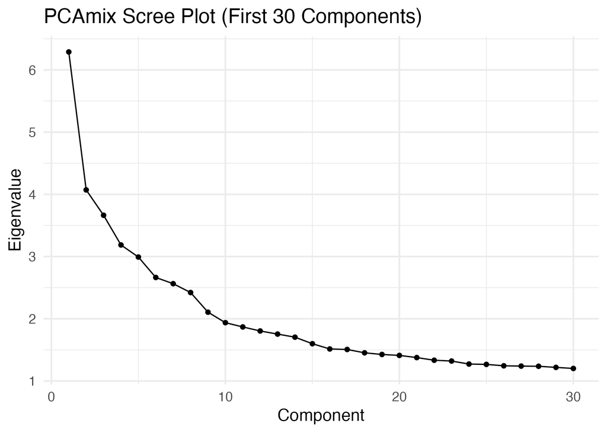

```r
pcamix_train <- PCAmix(
  X.quanti = X.quanti_train,
  X.quali  = X.quali_train,
  ndim     = ncol(train_x),
  rename.level = TRUE,
  graph = FALSE
)

k <- 30
eig <- pcamix_train$eig[1:k, ]

eig_df <- data.frame(
  Dim = 1:k,
  Eigenvalue = eig[, 1]
)

ggplot(eig_df, aes(x = Dim, y = Eigenvalue)) +
  geom_point() +
  geom_line() +
  theme_minimal(base_size = 14) +
  labs(
    title = "PCAmix Scree Plot (First 30 Components)",
    x = "Component",
    y = "Eigenvalue"
  )
```

## 5.3 Selection of 10 Principal Components

Component retention was guided by inspection of the PCAmix scree plot and the corresponding eigenvalues. The first several components show a steep decline in eigenvalue magnitude, with Components 1–10 all exceeding approximately 1.9 and capturing substantively meaningful variation. Beyond the tenth component, the eigenvalues flatten markedly, ranging narrowly between 1.86 and 1.20 through Component 30. This gradual, nearly linear decrease indicates the onset of the “long tail” region, where additional components contribute relatively little incremental explanatory power.

Although traditional rules such as Kaiser’s criterion (retaining components with eigenvalues > 1) would suggest keeping many more than ten components in this mixed-data setting, such heuristics are known to over-retain when the variable count is large and includes categorical indicators, as in PCAmix. Instead, we prioritized components that (a) lie above the clear elbow in the scree plot, (b) exhibit noticeably larger eigenvalue magnitude, and (c) are likely to support interpretable rotated factors. Under these criteria, a 10-component solution represents a balance between parsimony and fidelity, preserving the major dimensions of structure while avoiding inflation of weak, noise-driven components. This 10-PC solution was therefore used for rotation, interpretation, and downstream predictive modeling.

## 5.4 Fitting PCAmix and SVC with Bayesian Hyperparameter Optimization

```r
library(ParBayesianOptimization)
library(e1071)
library(rsample)
library(yardstick)
library(dplyr)
library(doParallel)

cl <- makeCluster(detectCores() - 1)
registerDoParallel(cl)

clusterExport(cl, varlist = c("train_scores_10_df", "class_weights"))

clusterEvalQ(cl, {
  library(e1071)
  library(rsample)      # <-- vfold_cv lives here
  library(yardstick)
  library(dplyr)
})

svm_cv_score <- function(cost, gamma) {
  # Guard against illegal values
  if (cost <= 0 || gamma <= 0) return(list(Score = -Inf))

  tryCatch({
    set.seed(123)
    folds <- vfold_cv(train_scores_10_df, v = 5, strata = success)

    pr_vals <- numeric(nrow(folds))
    for (i in seq_len(nrow(folds))) {
      split    <- folds$splits[[i]]
      train_i  <- analysis(split)
      test_i   <- assessment(split)

      mod <- svm(
        success ~ .,
        data = train_i,
        kernel = "radial",
        cost = cost,
        gamma = gamma,
        class.weights = class_weights,
        probability = TRUE
      )

      pred <- predict(mod, test_i, probability = TRUE)
      prob_low <- attr(pred, "probabilities")[, "low"]

      pr_vals[i] <- pr_auc_vec(test_i$success, prob_low,
                               event_level = "first")
    }

    list(Score = mean(pr_vals, na.rm = TRUE))
  }, error = function(e) {
    list(Score = -Inf)
  })
}

bounds <- list(
  cost  = c(0.1, 50),
  gamma = c(0.01, 2)
)

set.seed(123)

opt <- bayesOpt(
  FUN = svm_cv_score,
  bounds = bounds,
  initPoints = 10,
  iters.n = 30,
  iters.k = 4,
  acq = "ei",
  kappa = 2.576,
  eps = 0,
  parallel = TRUE,
  gsPoints = 200,
  acqThresh = 0.9,
  errorHandling = 10,
  plotProgress = TRUE,
  saveFile = "svm_bayes_opt.RDS",
  verbose = 2
)

stopCluster(cl)

best <- getBestPars(opt)
cat(sprintf("Best cost = %.3f, gamma = %.4f, CV PR-AUC = %.4f\n",
            best$cost, best$gamma, max(opt$scoreSummary$Score)))

final_svm_10 <- svm(
  success ~ .,
  data = train_scores_10_df,
  kernel = "radial",
  cost = best$cost,
  gamma = best$gamma,
  class.weights = class_weights,
  probability = TRUE
)

test_pred <- predict(final_svm_10, test_scores_10_df, probability = TRUE)
test_prob <- attr(test_pred, "probabilities")[, "low"]

test_pr_auc <- pr_auc_vec(test_scores_10_df$success, test_prob,
                          event_level = "first")
cat("Test PR-AUC =", test_pr_auc, "\n")
```

[output not shown]

To tune the radial-basis SVM classifier, we optimized two key hyperparameters: **cost** and **gamma**. The *cost* parameter regulates the penalty assigned to misclassified observations, where smaller values allow a softer and more flexible margin, while larger values enforce stricter separation that can lead to overfitting. The *gamma* parameter controls the width of the radial basis function kernel. Low gamma values generate smoother, more global decision boundaries, whereas high gamma values produce highly localized boundaries that risk capturing noise in the training set.

Because the dataset is strongly imbalanced—with *low-success* students being far less frequent than *high-success* students—we incorporated **class weights** directly in the SVM optimization. We computed weights proportional to the inverse class frequencies:

- **low**: 6.0256
- **high**: 1.0000

This weighting scheme forces the model to treat misclassification of the minority *low* class as roughly six times more costly than misclassification of a *high* case. Incorporating class weights prevents the classifier from defaulting to the majority class and ensures that the decision boundary is shaped to improve detection of the students most relevant to our prediction objective.

Hyperparameter performance was evaluated using **five-fold stratified cross-validation**, preserving the proportion of low and high cases in each fold. For each (cost, gamma) pair proposed by the Bayesian optimizer, the SVM was trained on four folds and evaluated on the remaining fold. Performance was quantified using the **Precision–Recall Area Under the Curve (PR-AUC)** computed for the *low* class. PR-AUC was chosen instead of ROC-AUC because the outcome is imbalanced: PR-AUC more directly measures how well the classifier identifies and ranks the minority group, which is the primary target for early detection and intervention.

Bayesian optimization (using an Expected Improvement acquisition function) efficiently searched the hyperparameter space, balancing exploration of uncertain regions and exploitation of promising ones. The process converged on a well-regularized configuration: **cost = 0.10** and **gamma = 0.01**, yielding a **cross-validated PR-AUC of 0.5811**. Training a final model on the full training set with these tuned parameters produced a **test-set PR-AUC of 0.6340**, indicating improved generalization and effective discrimination of low-success students despite substantial class imbalance.

## 5.5 Relationship Between Hyperparameters and Model Performance

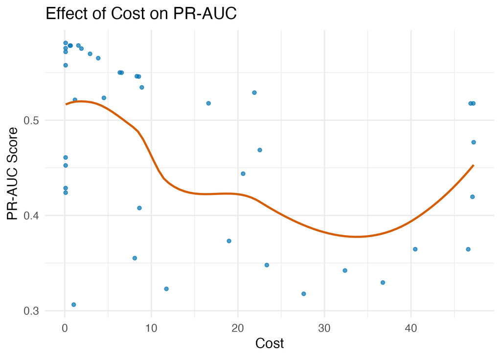

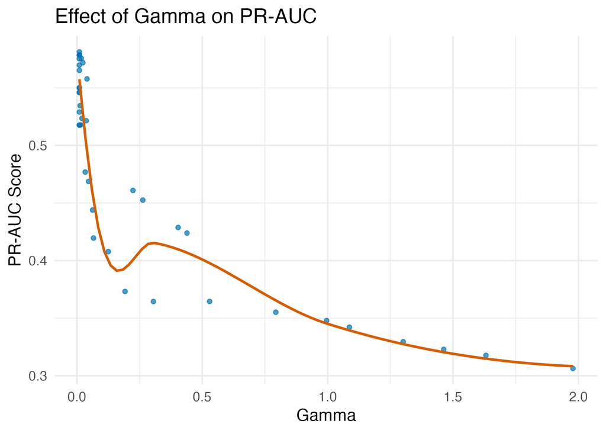

The scatter plots of PR-AUC against **cost** and **gamma** reveal a clear structural pattern in how the SVM responds to regularization. Models achieve their strongest performance when **cost is small** and **gamma is extremely small**, indicating that the classifier benefits from a **soft margin** and a **very smooth, broad RBF kernel**. As either hyperparameter increases—especially when gamma becomes moderate or large—the PR-AUC drops sharply. This pattern shows that highly flexible or highly localized decision boundaries (high gamma or high cost) tend to overfit the majority class and degrade ranking performance for the minority *low-success* group. Conversely, the highest PR-AUC values cluster in the region where the boundary is simple and heavily regularized, consistent with the final optimal configuration (cost = 0.10, gamma = 0.01).

## 5.6 SVM Confusion Matrix on Test Data

[figure not shown]

The confusion matrix displays predicted classes on the rows and true classes on the columns. Thus, each cell reflects how often the model assigned a given label relative to the actual outcome.

- **Predicted low / True low (TP)**: 221
- **Predicted low / True high (FP)**: 320
- **Predicted high / True low (FN)**: 26
- **Predicted high / True high (TN)**: 1302

Interpreting *low* as the at-risk (positive) class:

- **Recall (sensitivity)** = 221 / (221 + 26) ≈ **89.5%**
  - The model correctly identifies most low-success students and rarely misses them.
- **Precision** = 221 / (221 + 320) ≈ **40.8%**
  - Of all students predicted to be low-success, only about 41% actually are; the remainder are false alarms.
- **Overall accuracy** ≈ (221 + 1302) / (221 + 320 + 26 + 1302) ≈ **81.5%**

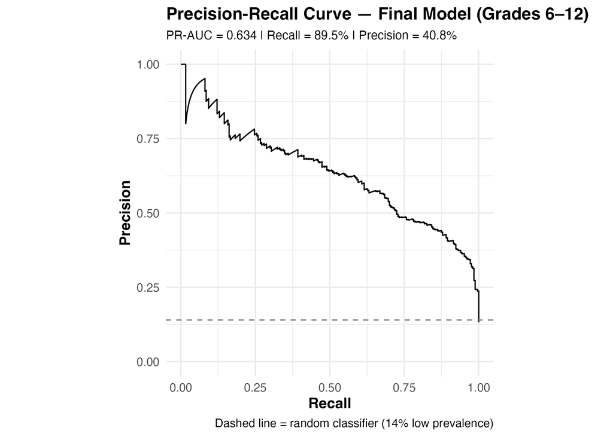

The precision–recall curve illustrates how the model balances correctly identifying low-success students (recall) against the proportion of flagged students who are truly low-success (precision). The model achieves strong recall across most thresholds, reflecting its ability to detect the majority of at-risk students, while maintaining precision well above the random-chance baseline of 14%. The resulting PR-AUC of 0.634 indicates substantially better minority-class ranking performance than would be expected by chance.

These results indicate that the model is optimized toward **high recall for the low-success group**, which aligns with the project goal of minimizing false negatives (i.e., failing to detect at-risk students). The tradeoff is a higher false-positive rate, meaning some high-success students are flagged as low. This pattern is consistent with the class weighting and the PR-AUC–driven tuning procedure, which prioritize identifying as many at-risk students as possible.

Importantly, in an educational context, the “cost” of these false positives may not be strictly negative. Students incorrectly flagged as low-success may still benefit from additional academic support, mentoring, or resource allocation. Such interventions can reinforce positive behaviors, bolster engagement, and help counteract patterns associated with multigenerational academic disadvantage. Thus, while the model errs on the side of over-identification, this may serve a broader equity-oriented purpose by expanding access to supportive structures that promote long-term success.

## 5.7 Comparison of Alternative SVM Models

The **5-component model** exhibited moderate performance, with a test PR-AUC of 0.517 and a noticeable decline in ROC-AUC and overall accuracy. Its recall for the low-success group dropped to 0.814, and the number of false negatives nearly doubled relative to the 10-component model. Despite flagging more students overall, its precision remained lower, suggesting weaker minority-class ranking ability.

The **3-component model** performed the weakest of the three. With a test PR-AUC of 0.475 and the lowest ROC-AUC (0.849), this model struggled to separate low- and high-success students. Recall fell to 0.785, and false negatives increased to 53. Although it produced fewer false positives than the 5-component model, its lower discriminative performance suggests that substantial predictive signal was lost when reducing the dimensionality to three components. Overall, the comparison indicates that reducing the PCAmix representation too aggressively degrades minority-class detection and ranking quality. The **10-component model** offers the most balanced and effective performance, preserving enough mixed-data structure to support high recall and strong PR-AUC while maintaining acceptable precision and accuracy.

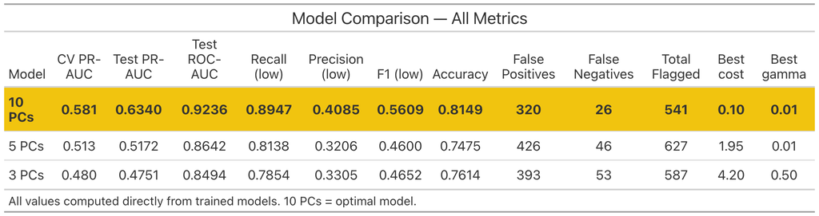

# 6 Model Selection

After completing three separate modeling approaches (LDA, LASSO Logistic Regression, and SVM Classifier) we observed clear differences in predictive performance, with our main focus being on the identification of low performing students.

LDA did decently well for the majority of high students (overall accuracy ≈ 66%) but struggled with low students (recall =58%, precision =21%, F1-Score =0.31). The LDA distributions showed significant overlap, showing how low-performing students were misclassified, which could pose issues as students who may need the extra help would not receive it.

LASSO Logistic Regression appeared to have the best overall predictive ability, with 91.6% accuracy and an AUC of 0.9337. While recall for the low-success class was low (30.54%), an good precision score (89.47%), and had an excellent overall accuracy (91.6%) the model still misclassified low-success students as high at an alarming rate. Which is bound to happen as no model ever has been 100% completely perfect without multicollinearity and overfitting the data.

SVM Classifier achieved a high recall (=89.5%) for low-success students, and had a mediocre precision score (=40.8%) and overall accuracy (=81.5%). The PR-AUC (0.634) showed strong low ranking performance, and the precision–recall curve shows the model’s capacity to detect at-risk low students consistently.

Overall, if our goal is to identify those students who are in desperate need of help (Low students), we will want to pick the model that best predicts those students who are low and are predicted low at a high rate, but more importantly having a low rate of students who are predicted high who are low. Right away, we can tell that it is between our LDA and our SVM Classifier models to use as our final model as LASSO had a lower recall accuracy compared to the other two.

So between our LDA and SVM Classifier models. Looking at both, they each have very different recall percentages indicating that one correctly predicts a low student at a better rate. Our biggest concern is looking at our recall percentage as we do not want to identify low students as high as they will not receive the needed help. With that, our best model would be our SVM Classifier model as it blows LASSO and LDA out with an extremely high value of 89.5% as LDA only has a recall percentage of 58% which is significantly lower then our SVM Classifier model.

In conclusion, our final chosen model is the SVM Classifier model, as it maintains a better recall value than the LASSO model and LDA model. In addition, this model will give us the best chance at identifying low students correctly, provides very few false negatives (predicted high but is low), and still provides a serviceable precision score.